# ggplot2 Continued

Albert Y. Kim  
Wednesday 2015/01/28

### Review Exercise from Last Time

- Go to top menu bar of RStudio -> File -> New File -> R Script
- Click on “Lec02 Exercise” in Moodle
- Copy contents and paste into R Script

### Last Time: Basic Components

- **`aes`** mappings of data variables to aesthetics we can perceive on a graphic
- **`geom`** geometric objects
- **`stat`** statistical transformations to summarise data
- **`facet`** how to break up plots into subsets
- **`coord`** coordinate system for x/y values: typically cartesian (can be polar)
- **`scale`** both convert **data units** to **physical units** the computer can display AND draw a legend/axes.
- **Extras** titles, axes labels, themes

### Further Reading Ressources

- Help files. Ex `?geom_line()`
- Online help files: http://docs.ggplot2.org/current/
- [Ultimate Tech Support](http://xkcd.com/627/)
- ggplot2 book is on Moodle. To learn more, I suggest reading
  - Chapter 1,
  - Chapter 3, but it will be hard to grasp the first time
  - Chapter 4
  - Revisit Chapter 3. Chapters 5-10 go into specific details.
- The code for all examples in the book: http://ggplot2.org/book/

### Today: More Components/Concepts

- **layers**: mechanism by which additional data elements are added to a plot
- **`position`** adjustments: minor tweeks to the position of elements
- **groups**: splitting data into groups within the same plot (not via facets)

### Building a Graphic Layer-by-Layer

We build plots by adding **layers**. Each layer consists of:

1. data and aesthetic mappings (the base)
2. geometric object
3. statistical transformation (with default values)
4. position adjustment (with default values)

Without all four elements specified, nothing will plot!

### Building a Graphic Layer-by-Layer

Notes:

- Make the base as general as possible
- Every `geom` has a default `stat` & `position` value if they aren't specified
- Layer settings override plot defaults
- You can save plots as variables and add to variables, to reduce duplication

### Examples for Today

In `ggplot_2.R` we have examples of

- setting groups: `Examples of groups`.
- many different types of geoms: `Examples of geoms`.
- `geom_histogram()` and **position adjustments**: [Titanic Survival Data](https://www.youtube.com/watch?v=zisjRgcuL9k)

### Today's Question: UC Berkeley Admissions

In 1973, the UC Berkeley was sued for bias against women who had applied for admission to graduate schools. n=4526 applicants:

```
Source: local data frame [4 x 3]
Groups: Admit

     Admit Gender Freq
1 Admitted   Male 1198
2 Admitted Female  557
3 Rejected   Male 1493
4 Rejected Female 1278
```

### Today's Question: UC Berkeley Admissions

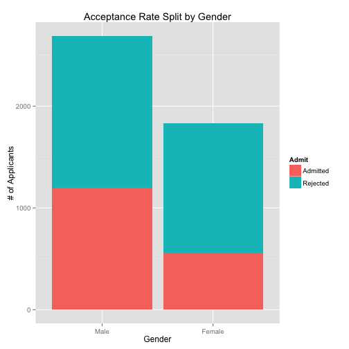

### Today's Question: UC Berkeley Admissions

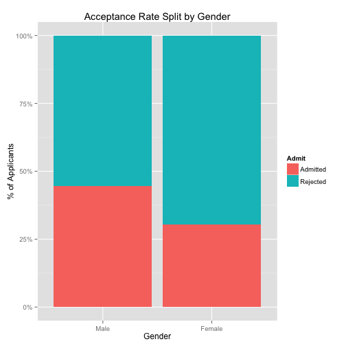

### Today's Question: UC Berkeley Admissions

However, there was another variable researchers could consider: department applied to.

```
Source: local data frame [24 x 4]

      Admit Gender Dept Freq
1  Admitted   Male    A  512
2  Rejected   Male    A  313
3  Admitted Female    A   89
4  Rejected Female    A   19
5  Admitted   Male    B  353
6  Rejected   Male    B  207
7  Admitted Female    B   17
8  Rejected Female    B    8
9  Admitted   Male    C  120
10 Rejected   Male    C  205
..      ...    ...  ...  ...
```

### Today's Question: UC Berkeley Admissions

Investigate:

1. Construct a statistical graphic showing how male vs female acceptance varied by department. Bonus: Using google, make one of the axes reflect percentage of applicants.
2. Construct a statistical graphic showing the “competitiveness” of the department as measured by acceptance rate.